# data609hw9

jim lung

November 1, 2018

## Section 10.1, Problem 1

### Part a

$$\begin{array}{crccc}
\ & \ & \ & \textbf{Colin} & \ \\
\ & \ & \textbf{C1} & \ & \textbf{C2} \\
\ & \textbf{R1} & 10 & \Longleftrightarrow & 10 \\
\textbf{Rose} & \ & \Uparrow & \ & \Uparrow \\
\ & \textbf{R2} & 10 & \Longrightarrow & 10
\end{array}$$

The game has a pure Nash equilibrium with a value of 10. Strategy R1 maximizes Rose’s value regardless of Colin’s strategy. While the value can be achieved at more than one combination of strategies, it is still a Nash equilibrium since neither party can benefit by departing from that strategy (i.e. either (R1, C1) or (R2, C2)).

### Part c

$$\begin{array}{crccc}
\ & \ & \ & \textbf{Pitcher} & \ \\
\ & \ & \textbf{Fastball} & \ & \textbf{Knuckleball} \\
\ & \textbf{Guesses fastball} & 0.400 & \Longrightarrow & 0.100 \\
\textbf{Batter} & \ & \Uparrow & \ & \Downarrow \\
\ & \textbf{Guesses knuckleball} & 0.300 & \Longrightarrow & 0.250
\end{array}$$

The game has a pure Nash equilibrium with a value of 0.250. Pitcher strategy *Knuckleball* minimizes the score regardless of batter strategy; given this pitcher strategy, batter strategy *Guess knuckleball* maximizes the score.

## Section 10.2, Problem 2a

$$\textrm{Maximize }P$$
Subject to
$$\begin{array}{c}
P \leq 10x + 5(1-x) \\
P \leq 10x \\
x \geq 0 \\
x \leq 1
\end{array}$$

If $y$ represents the portion of the time that Colin plays strategy C1, then the expected value of $P$ is $10y + 10(1-y) = 10$ if Rose plays purely strategy R1 and $5y$ if Rose plays purely strategy R2. This means that, for Colin, the linear program is

$$\textrm{Minimize }P$$
Subject to
$$\begin{array}{c}
P \geq 10 \\
P \geq 5y \\
x \geq 0 \\
x \leq 1
\end{array}$$

### Geometric Solution

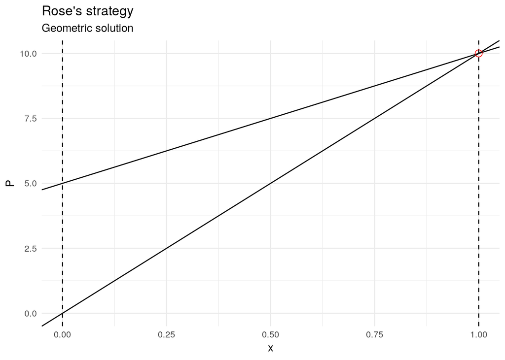

From this graph, any solution along or below the line $P = 10x$ is a feasible solution in the range $0 \leq x \leq 1$. The maximized value of $P$ is $P = 10$ at $x = 1$ – if Rose plays strategy R1 100% of the time, she is guaranteed a maximum payoff of 10.

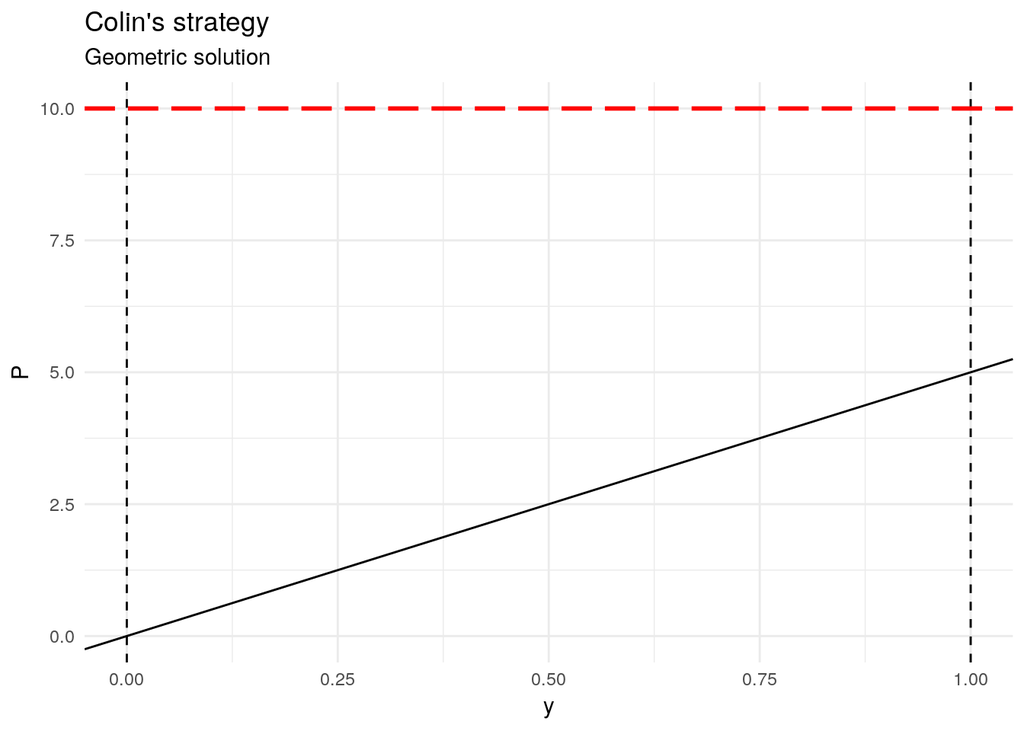

This graph shows that there is no optimal strategy for Colin – regardless of his mix of strategies, the furthest he can minimize the payoff is to $P=10$. Due to this, Colin should likely play a strategy of pure C2, as this places him in the best position to take advantage of suboptimal play by Rose.

### Algebraic Solution

For Rose, the intersection points of the above-stated constraints are shown below:

| x | P | Feasible |
| --- | --- | --- |
| 0 | 0 | Y |
| **1** | **10** | **Y** |
| 0 | 5 | N |
| **1** | **10** | **Y** |

For Colin, the values are below:

| x | P | Feasible |
| --- | --- | --- |
| **0** | **10** | **Y** |
| **1** | **10** | **Y** |
| 0 | 0 | N |
| 1 | 5 | N |

As in the geometric solution, the best strategy for Rose is $x=1$ i.e. always playing strategy R1, and Colin’s strategy does not matter.

## Section 10.3, Problem 3

### Investor’s Game

For the investor, the variables of interest are

- $P$ = Payoff
- $x_A$ = Portion of the time to play alternative A
- $x_B$ = Portion of the time to play alternative B
- $x_C$ = Portion of the time to play alternative C

```
Success: the objective function is 4125
```

The optimal strategy for the investor is $x_A = 0.25$, $x_B = 0$, $x_C = 0.75$, which yields an optimal payoff of $P = 4125$.

### Economy’s Game

For the economy, the variables of interest are

- $P$ = Payoff
- $y_1$ = Portion of the time to play condition 1
- $y_2$ = Portion of the time to play condition 2
- $y_3$ = Portion of the time to play condition 3

The linear program is
$$\textrm{Minimize }P$$
Subject to
$$\begin{array}{rl}
3000y_1 + 4500y_2 + 6000y_3 - P \leq 0 & Alternative\ A\\
1000y_1 + 9000y_2 + 2000y_3 - P \leq 0 & Alternative\ B\\
4500y_1 + 4000y_2 + 3500y_3 - P \leq 0 & Alternative\ C\\
y_1, y_2, y_3 \geq 0 \\
y_1, y_2, y_3 \leq 1 \\
y_1 + y_2 + y_3 = 1 \\
P \geq 0
\end{array}$$

The economy’s program is solved in the same way as the investor’s:

```
Success: the objective function is 4125
```

The optimal strategy for the economy is $y_1 = 0.625$, $y_2 = 0$, $y_3 = 0.375$, which yields an optimal payoff of $P = 4125$.

## Section 10.5, Problem 3

### Equating Expected Values

For Rose, the expected value under each of Colin’s strategies are
$$\begin{aligned}
E(C1) &= 0.5x + 0.6(1-x) \\
E(C2) &= 0.3x + 1(1-x)
\end{aligned}$$

where $x$ is the portion of the time Rose uses strategy R1. Setting these equal to one another and solving,

$$0.5x + 0.6(1-x) = 0.3x + 1(1-x) \longrightarrow x = \frac{2}{3}; 1-x = \frac{1}{3}$$
The value of the game is
$$E(C1) = 0.5x + 0.6(1-x) = \frac{8}{15} \approx 0.5333$$

For Colin, the expected value under each of Rose’s strategies are
$$\begin{aligned}
E(R1) &= 0.5y + 0.3(1-y) \\
E(R2) &= 0.6y + 1(1-y)
\end{aligned}$$

where $y$ is the portion of the time Colin uses strategy C1. Setting these equal to one another and solving,

$$0.5y + 0.3(1-y) = 0.6y + 1(1-y) \longrightarrow y = \frac{7}{6}; 1-y = -\frac{1}{6}$$

Clearly this is a violation of the condition $0 \leq y \leq 0$ that applies since $y$ is a probability. Nonetheless, the value of the game is calculated:
$$E(R1) = 0.5y + 0.3(1-y) = \frac{7}{12} - \frac{3}{60} = \frac{8}{15} \approx 0.5333$$

### Method of Oddments

As above, the solution does not produce useful results:

|  | **C1** | **C2** | **$[\Delta]$** |
| --- | --- | --- | --- |
| **R1** | 0.5 | 0.3 | 0.2 |
| **R2** | 0.6 | 1 | 0.4 |
| **$[\Delta]$** | 0.1 | 0.7 | $0.6 \neq 0.8$ |

## Section 10.6, Problem 2

There is a stable Nash equilibrium at $(2,4)$ – neither player can utilaterally improve from this position.

Rose would rather Colin play C2, as it increases her potential payoff. To do this, she can issue a threat:

> *If Colin plays C1, Rose will play R1* This meets the critera for a threat:
- it is contingent on Colin’s action
- it harms Rose (lowers her payoff from 2 playing R2 to 1 playing R1)
- it is harmful to Colin (lowers his payoff from R under R2 to 2 under R1)

The game then becomes
$$\begin{array}{crccc}
\ & \ & \ & \textbf{Colin} & \ \\
\ & \ & \textbf{C1} & \ & \textbf{C2} \\
\ & \textbf{R1} & (1,2) & \Longrightarrow & (3,1) \\
\textbf{Rose} & \ & & \ & \Downarrow \\
\ & \textbf{R2} & Eliminated & & (4,3)
\end{array}$$

Thus Colin will choose strategy C2, and Rose will choose strategy R2, maximizing her payoff at $(4, 3)$.

## Section 10.7, Problem 3

To get the table of payoffs, the probabilities must be matched in a 3-by-3 grid and multiplied by the associated payoff per each outcome and summing the two numbers:

$$\begin{array}{cccc}
\ & \textbf{IL} & \textbf{IM} & \textbf{IC} \\
\textbf{DL} & (3, -5) & (3, -10) & (3, -10)\\
\textbf{DM} & (10, -5) & (8, -6) & (8, -10)\\
\textbf{DC} & (10, -5) & (10, -6) & (10, -10)\\
\end{array}$$

Summing these values and completing the movement diagram yields

$$\begin{array}{cccccc}
\ & \textbf{IL} & \ & \textbf{IM} & \ & \textbf{IC} \\
\textbf{DL} & -2 & \Rightarrow & -7 & \Leftrightarrow & -7\\
\ & \Downarrow & \ & \Downarrow & \ & \Downarrow \\
\textbf{DM} & 5 & \ & 2 \ & & -2\\
\ & \Updownarrow & \ & \Downarrow & \ & \Downarrow \\
\textbf{DC} & 5 & \Rightarrow & 4 & \Rightarrow & 0\\
\end{array}$$

There is a nash equilibrium at (DC, IC) – here the game has a value of 0 and neither player can unilaterally improve.